# Bay Wheels's trip data set

## by Abdulrahman Alsalem

```python
# import all packages and set plots to be embedded inline
import numpy as np
import pandas as pd
import matplotlib.pyplot as plt
import seaborn as sb

%matplotlib inline
```

```python
# load in the dataset into a pandas dataframe.
df = pd.read_csv('2017-fordgobike-tripdata.csv')
```

```python
# high-level overview of data shape and composition
print(df.shape)
print(df.dtypes)
print(df.isna().sum())
df.head(5)
```

```
(519700, 15)
duration_sec                 int64
start_time                  object
end_time                    object
start_station_id             int64
start_station_name          object
start_station_latitude     float64
start_station_longitude    float64
end_station_id               int64
end_station_name            object
end_station_latitude       float64
end_station_longitude      float64
bike_id                      int64
user_type                   object
member_birth_year          float64
member_gender               object
dtype: object
duration_sec                   0
start_time                     0
end_time                       0
start_station_id               0
start_station_name             0
start_station_latitude         0
start_station_longitude        0
end_station_id                 0
end_station_name               0
end_station_latitude           0
end_station_longitude          0
bike_id                        0
user_type                      0
member_birth_year          66541
member_gender              66462
dtype: int64
```

|  | duration_sec | start_time | end_time | start_station_id | start_station_name | start_station_latitude | start_station_longitude | end_station_id | end_station_name | end_station_latitude | end_station_longitude | bike_id | user_type | member_birth_year | member_gender |
| --- | --- | --- | --- | --- | --- | --- | --- | --- | --- | --- | --- | --- | --- | --- | --- |
| 0 | 80110 | 2017-12-31 16:57:39.6540 | 2018-01-01 15:12:50.2450 | 74 | Laguna St at Hayes St | 37.776435 | -122.426244 | 43 | San Francisco Public Library (Grove St at Hyde... | 37.778768 | -122.415929 | 96 | Customer | 1987.0 | Male |
| 1 | 78800 | 2017-12-31 15:56:34.8420 | 2018-01-01 13:49:55.6170 | 284 | Yerba Buena Center for the Arts (Howard St at ... | 37.784872 | -122.400876 | 96 | Dolores St at 15th St | 37.766210 | -122.426614 | 88 | Customer | 1965.0 | Female |
| 2 | 45768 | 2017-12-31 22:45:48.4110 | 2018-01-01 11:28:36.8830 | 245 | Downtown Berkeley BART | 37.870348 | -122.267764 | 245 | Downtown Berkeley BART | 37.870348 | -122.267764 | 1094 | Customer | NaN | NaN |
| 3 | 62172 | 2017-12-31 17:31:10.6360 | 2018-01-01 10:47:23.5310 | 60 | 8th St at Ringold St | 37.774520 | -122.409449 | 5 | Powell St BART Station (Market St at 5th St) | 37.783899 | -122.408445 | 2831 | Customer | NaN | NaN |
| 4 | 43603 | 2017-12-31 14:23:14.0010 | 2018-01-01 02:29:57.5710 | 239 | Bancroft Way at Telegraph Ave | 37.868813 | -122.258764 | 247 | Fulton St at Bancroft Way | 37.867789 | -122.265896 | 3167 | Subscriber | 1997.0 | Female |

```python
# drop the rows that have null values.
df = df.dropna()
```

```python
df.shape
```

```
(453159, 15)
```

### What is/are the main feature(s) of interest in your dataset?

> My interest to find what are the main characteristics for the majority duration trips.

### What features in the dataset do you think will help support your investigation into your feature(s) of interest?

> Trip duration, Gender, User Type, Age of the rider.

## Univariate Exploration

```python
# change from seconds to minutes to easier understanding.
df['duration_sec'] = df['duration_sec']/60
```

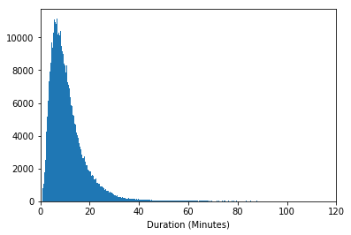

```python
# show trips distrbution.
plt.hist(data = df, x = 'duration_sec', bins= 5000)
plt.xlim([0,120])
plt.xlabel('Duration (Minutes)')
plt.show()
```

```python
# show the average trip's duration.
(df['duration_sec']).mean()
```

```
13.882233572175334
```

```python
# show the outliers durations.
(df[df['duration_sec'] > 60]['duration_sec']).count()
```

```
5524
```

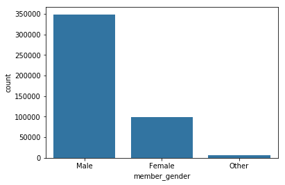

```python
# see if there undefined gender
default_color = sb.color_palette()[0]
sb.countplot(data = df, x = 'member_gender', color = default_color);
plt.show()
```

```python
# show how many undefined genders.
(df[df['member_gender'] == 'Other']['member_gender']).count()
```

```
6299
```

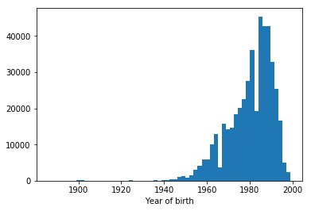

```python
# see if there outliers years
plt.hist(data = df, x = 'member_birth_year', bins= 60)
plt.xlabel('Year of birth')
plt.show()
```

```python
# see outliers years of birth
(df[df['member_birth_year'] < 1940]['member_birth_year']).count()
```

```
747
```

```python
# drop the outliers.
df = df[df['duration_sec'] < 60]
df = df[df['member_birth_year'] > 1940]
df = df[df['member_gender'] != 'Other']
```

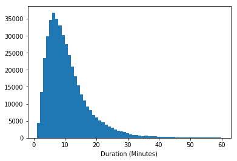

```python
# see our durations after cleaning
plt.hist(data = df, x = 'duration_sec', bins= 60)
plt.xlabel('Duration (Minutes)')
plt.show()
```

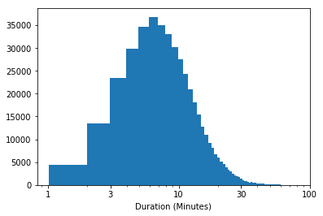

```python
# there's a long tail in the distribution, put it on a log scale instead
plt.hist(data = df, x = 'duration_sec', bins= 60)
ticks = [1, 3, 10, 30, 100]
lables = ['{}'.format(v) for v in ticks]
plt.xscale('log')
plt.xlabel('Duration (Minutes)')
plt.xticks(ticks, lables)
plt.show()
```

> We can conclude that our main durations are between 1-10 minutes, and this is our data that we will investigate it's characteristics more.

```python
# new data frame to foucs in our interest.
df2 = df[df['duration_sec'] < 10]
```

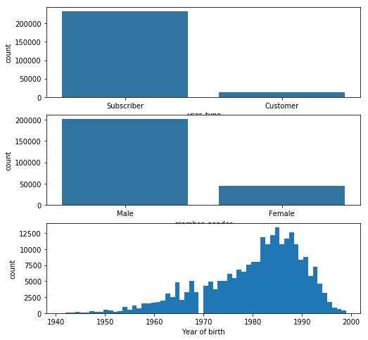

```python
fig, ax = plt.subplots(nrows=3, figsize = [8,8])
default_color = sb.color_palette()[0]
sb.countplot(data = df2, x = 'user_type', color = default_color, ax = ax[0]);
sb.countplot(data = df2, x = 'member_gender', color = default_color, ax = ax[1]);
plt.hist(data = df2, x = 'member_birth_year', bins= 60)
plt.xlabel('Year of birth')
plt.ylabel('count')
plt.show()
plt.show()
```

### Discuss the distribution(s) of your variable(s) of interest. Were there any unusual points? Did you need to perform any transformations?

> Yes, there was long tail in the distribution, we perform log transformation.

### Of the features you investigated, were there any unusual distributions? Did you perform any operations on the data to tidy, adjust, or change the form of the data? If so, why did you do this?

> First, take duration by minutes rather than seconds to be easy to imagine the data. Second, discard missing values. Third, remove outliers to not be distracted by them.

## Bivariate Exploration

```python
numeric_vars = ['duration_sec', 'member_birth_year']
categoric_vars = ['user_type', 'member_gender']
```

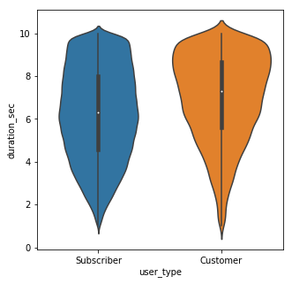

```python
plt.figure(figsize = [5, 5])
sb.violinplot(data = df2, x = 'user_type', y = 'duration_sec')
plt.show()
```

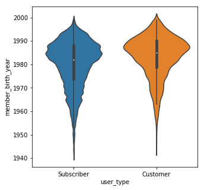

```python
plt.figure(figsize = [5, 5])
sb.violinplot(data = df2, x = 'user_type', y = 'member_birth_year')
plt.show()
```

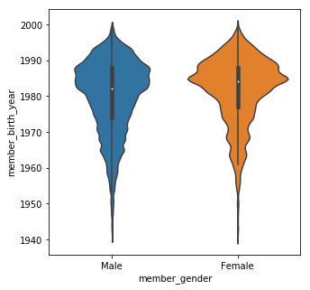

```python
plt.figure(figsize = [5, 5])
sb.violinplot(data = df2, x = 'member_gender', y = 'member_birth_year')
plt.show()
```

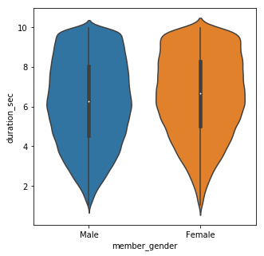

```python
plt.figure(figsize = [5, 5])
sb.violinplot(data = df2, x = 'member_gender', y = 'duration_sec')
plt.show()
```

### Did you observe any interesting relationships between the other features (not the main feature(s) of interest)?

> most of our riders are 23-33 years old.

## Multivariate Exploration

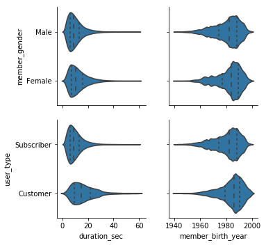

```python
g = sb.PairGrid(data = df, x_vars = ['duration_sec', 'member_birth_year'],
                y_vars = ['member_gender','user_type'])
g.map(sb.violinplot, inner = 'quartile')
```

### Talk about some of the relationships you observed in this part of the investigation. Were there features that strengthened each other in terms of looking at your feature(s) of interest?

> most of females riders are younger than males riders. subscribers spend less time than customers.

### Were there any interesting or surprising interactions between features?

> subscribers are older than customers.

> At the end of your report, make sure that you export the notebook as an html file from the `File > Download as... > HTML` menu. Make sure you keep track of where the exported file goes, so you can put it in the same folder as this notebook for project submission. Also, make sure you remove all of the quote-formatted guide notes like this one before you finish your report!